# Vaccine simulations

2024-01-16

## Introduction

We are interested in doing an analysis to look at effectiveness of different vaccines (i.e. monovalent vs bivalent) and effects. We have estimates of population by age, when they were vaccinated and a linelist of positive cases with their vaccine history. Before we fit to data, we are going to simulate some fake data to make sure we know what we are doing.

## Simulation

### Basic Sim

We are going to start from the basics and build our way up. We first start with a population and we vaccinate a group of them and compare the if the proportion of infections. Let’s assume the vaccine has VE = p and the proportion of people infected in the unvaccinated group is x. Then the proportion of vaccined that’s infected is x times (1-p).

- population = 10,000
- proportion vaccinated = 50%
- VE = 80%
- FOI = 5%

```
##     vax size prop
## 1 unvax 5000 0.05
## 2   vax 5000 0.01
```

### Basic fit

We are now going to fit it now.

```r
basic_fit <- glm(prop~vax
    , weights = size
    , data = basic_dat
    , family = binomial()
)

print(summary(basic_fit))
```

```
##
## Call:
## glm(formula = prop ~ vax, family = binomial(), data = basic_dat,
##     weights = size)
##
## Coefficients:
##             Estimate Std. Error z value Pr(>|z|)
## (Intercept) -2.94444    0.06489  -45.38   <2e-16 ***
## vaxvax      -1.65068    0.15625  -10.56   <2e-16 ***
## ---
## Signif. codes:  0 '***' 0.001 '**' 0.01 '*' 0.05 '.' 0.1 ' ' 1
##
## (Dispersion parameter for binomial family taken to be 1)
##
##     Null deviance:  1.4968e+02  on 1  degrees of freedom
## Residual deviance: -2.9976e-13  on 0  degrees of freedom
## AIC: 17.052
##
## Number of Fisher Scoring iterations: 3
```

We are going to use emmeans to get the effects.

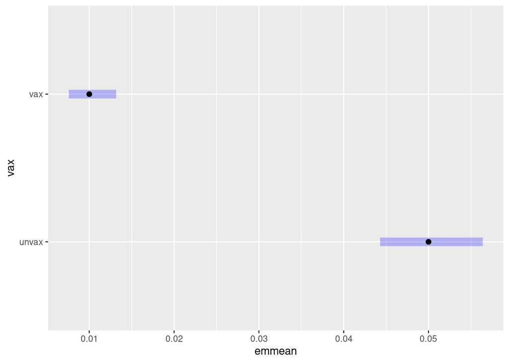

```r
library(emmeans)

basic_emm <- emmeans(basic_fit, ~vax, type = "response")

gg <- plot(basic_emm, type = "response")

print(gg)
```

Now we are going to try to recover VE using contrast.

```r
basic_con <- contrast(basic_emm)

print(basic_con)
```

```
##  contrast     odds.ratio     SE  df null z.ratio p.value
##  unvax effect      2.283 0.1783 Inf    1  10.565  <.0001
##  vax effect        0.438 0.0342 Inf    1 -10.565  <.0001
##
## P value adjustment: fdr method for 2 tests
## Tests are performed on the log odds ratio scale
```

```r
## Setting up the contrast

basic_con2 <- contrast(basic_emm
    , list(vax_vs_unvax = c(-1,1)
    )
)

print(basic_con2)
```

```
##  contrast     odds.ratio   SE  df null z.ratio p.value
##  vax_vs_unvax      0.192 0.03 Inf    1 -10.565  <.0001
##
## Tests are performed on the log odds ratio scale
```

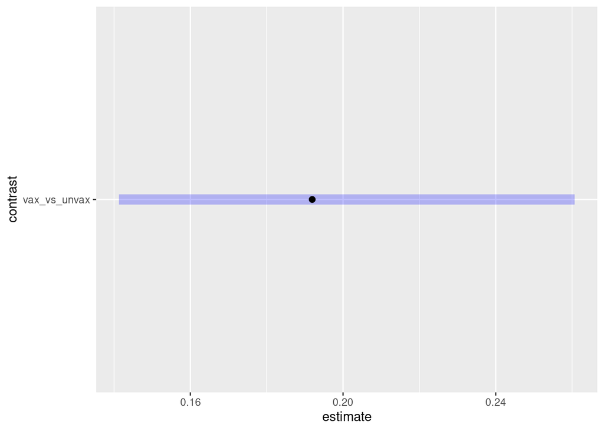

```r
print(plot(basic_con2))
```